# Customizing an MCMC

UW 2020 short course

NIMBLE Development Team

# NIMBLE’s default MCMC

Let’s see the results from running NIMBLE’s default MCMC again:

```r
occ_model <- nimbleModel(occ_code,
                        constants = occupancy_data,
                        inits = inits_saved)
```

```
## defining model...
```

```
## Detected y as data within 'constants'.
```

```
## Adding y as data for building model.
```

```
## building model...
```

```
## setting data and initial values...
```

```
## running calculate on model (any error reports that follow may simply reflect missing values in model variables) ...
## checking model sizes and dimensions...
## model building finished.
```

```r
occ_MCMC <- buildMCMC(occ_model)

Cocc_model <- compileNimble(occ_model)
```

```
## compiling... this may take a minute. Use 'showCompilerOutput = TRUE' to see C++ compilation details.
## compilation finished.
```

```r
Cocc_MCMC <- compileNimble(occ_MCMC, project = occ_model)
```

```
## compiling... this may take a minute. Use 'showCompilerOutput = TRUE' to see C++ compilation details.
## compilation finished.
```

```r
t1 <- system.time(samples1 <- runMCMC(Cocc_MCMC, niter = 2500, nburnin = 500))
```

```
## running chain 1...
```

```
## |-------------|-------------|-------------|-------------|
## |-------------------------------------------------------|
```

```r
library(coda, warn.conflicts = FALSE)
effectiveSize(samples1)
```

```
##    alpha1     beta1    mean.p  mean.psi
## 126.34907  36.71083 107.38837  30.86198
```

```r
effectiveSize(samples1) / t1['elapsed']
```

```
##    alpha1     beta1    mean.p  mean.psi
## 314.30118  91.32047 267.13525  76.77109
```

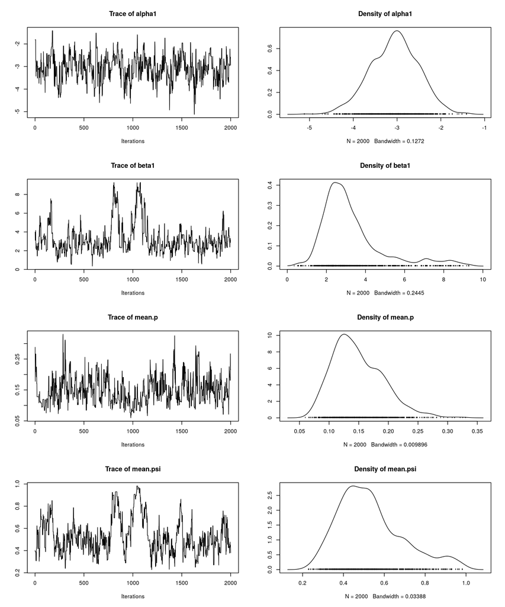

```r
plot(as.mcmc(samples1))
```

Note that the ESS per time counted the burn-in time, which we might want to omit if comparing pure efficiency of the samplers.

# Customizing samplers: examining the defaults

One of NIMBLE’s most important features is that users can easily modify the MCMC algorithm used for their model. The easiest thing to do is to start with NIMBLE’s default MCMC and then make modifications.

```r
# Explicitly set up the MCMC configuration to see the defaults.
conf <- configureMCMC(occ_model)
conf
```

```
## ===== Monitors =====
## thin = 1: mean.p, alpha1, mean.psi, beta1
## ===== Samplers =====
## RW sampler (4)
##   - mean.p
##   - alpha1
##   - mean.psi
##   - beta1
## binary sampler (100)
##   - z[]  (100 elements)
```

```r
conf$printSamplers()
```

```
## [1]   RW sampler: mean.p
## [2]   RW sampler: alpha1
## [3]   RW sampler: mean.psi
## [4]   RW sampler: beta1
## [5]   binary sampler: z[1]
## [6]   binary sampler: z[2]
## [7]   binary sampler: z[3]
## [8]   binary sampler: z[4]
## [9]   binary sampler: z[5]
## [10]  binary sampler: z[6]
## [11]  binary sampler: z[7]
## [12]  binary sampler: z[8]
## [13]  binary sampler: z[9]
## [14]  binary sampler: z[10]
## [15]  binary sampler: z[11]
```

[output cut: 89 more lines]

# Customizing samplers: modifying the samplers

```r
conf <- configureMCMC(occ_model)
params <- occ_model$getNodeNames(topOnly = TRUE)
params
```

```
## [1] "mean.p"   "alpha1"   "mean.psi" "beta1"
```

```r
conf$removeSamplers(params)
for(p in params)
    conf$addSampler(p, type = 'slice')

occ_MCMC <- buildMCMC(conf)

## We need 'resetFunctions' because we are rebuilding the MCMC for
## an existing model for which we've already done some compilation.
Cocc_MCMC <- compileNimble(occ_MCMC, project = occ_model, resetFunctions = TRUE)
```

```
## compiling... this may take a minute. Use 'showCompilerOutput = TRUE' to see C++ compilation details.
```

```
## compilation finished.
```

```r
t2 <- system.time(samples2 <- runMCMC(Cocc_MCMC, niter = 2500, nburnin = 500))
```

```
## running chain 1...
```

```
## |-------------|-------------|-------------|-------------|
## |-------------------------------------------------------|
```

```r
effectiveSize(samples2)
```

```
##   alpha1    beta1   mean.p mean.psi
## 438.2461 193.8374 306.6175 132.0146
```

```r
effectiveSize(samples2) / t2['elapsed']
```

```
##   alpha1    beta1   mean.p mean.psi
## 376.5001 166.5269 263.4171 113.4146
```

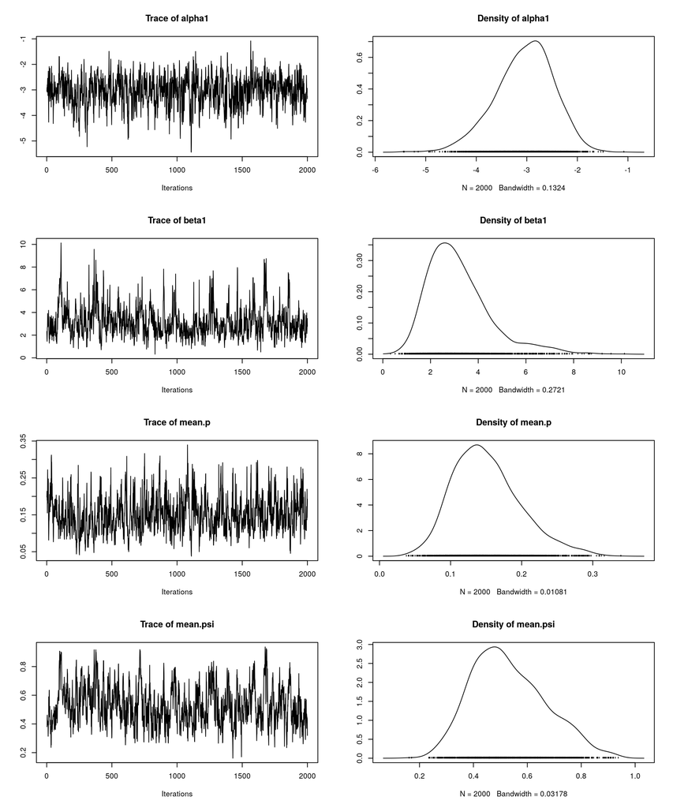

```r
plot(as.mcmc(samples2))
```

# Blocking parameters

Often a key factor that reduces MCMC performance is dependence between parameters that limits the ability of univariate samplers to move very far. A standard strategy is to sample correlated parameters in blocks. Unlike many other MCMC engines, NIMBLE makes it easy for users to choose what parameters to sample in blocks.

Let’s look at posterior correlation here.

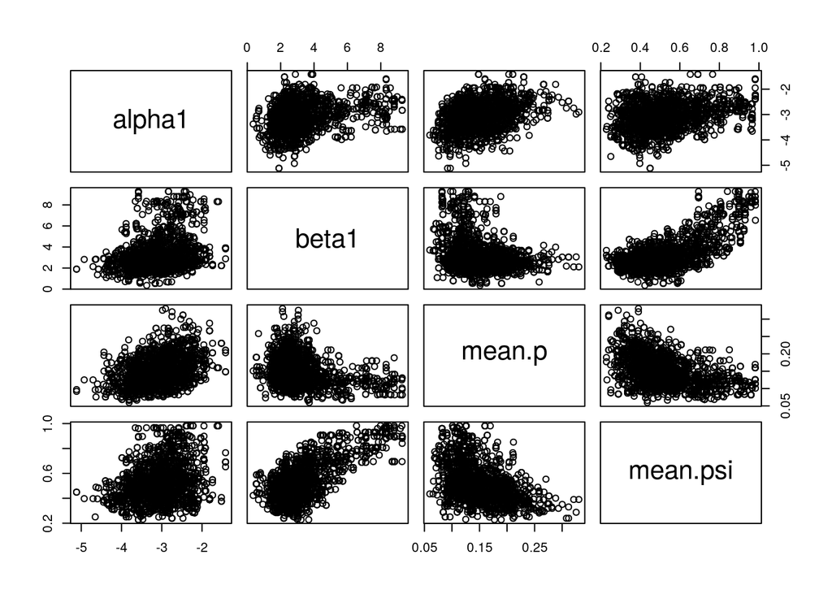

```r
plot(as.data.frame(samples1))
```

# Using NIMBLE’s RW_block sampler

```r
conf <- configureMCMC(occ_model)

block <- c('alpha1','mean.p')
for(p in block)
    conf$removeSamplers(p)
conf$addSampler(block, type = 'RW_block')
```

```
## Note: Assigning an RW_block sampler to nodes with very different scales can result in low MCMC efficiency.  If all nodes assigned to RW_block are not on a similar scale, we recommend providing an informed value for the "propCov" control list argument, or using the AFSS sampler instead.
```

```r
occ_MCMC <- buildMCMC(conf)
Cocc_MCMC <- compileNimble(occ_MCMC, project = occ_model, resetFunctions = TRUE)
```

```
## compiling... this may take a minute. Use 'showCompilerOutput = TRUE' to see C++ compilation details.
```

```
## compilation finished.
```

```r
t3 <- system.time(samples3 <- runMCMC(Cocc_MCMC, niter = 2500, nburnin = 500))
```

```
## running chain 1...
```

```
## |-------------|-------------|-------------|-------------|
## |-------------------------------------------------------|
```

```r
effectiveSize(samples3)
```

```
##    alpha1     beta1    mean.p  mean.psi
##  6.465458 51.758164 77.606498 53.267501
```

```r
effectiveSize(samples3) / t3['elapsed']
```

```
##    alpha1     beta1    mean.p  mean.psi
##  20.26789 162.25130 243.28056 166.98276
```

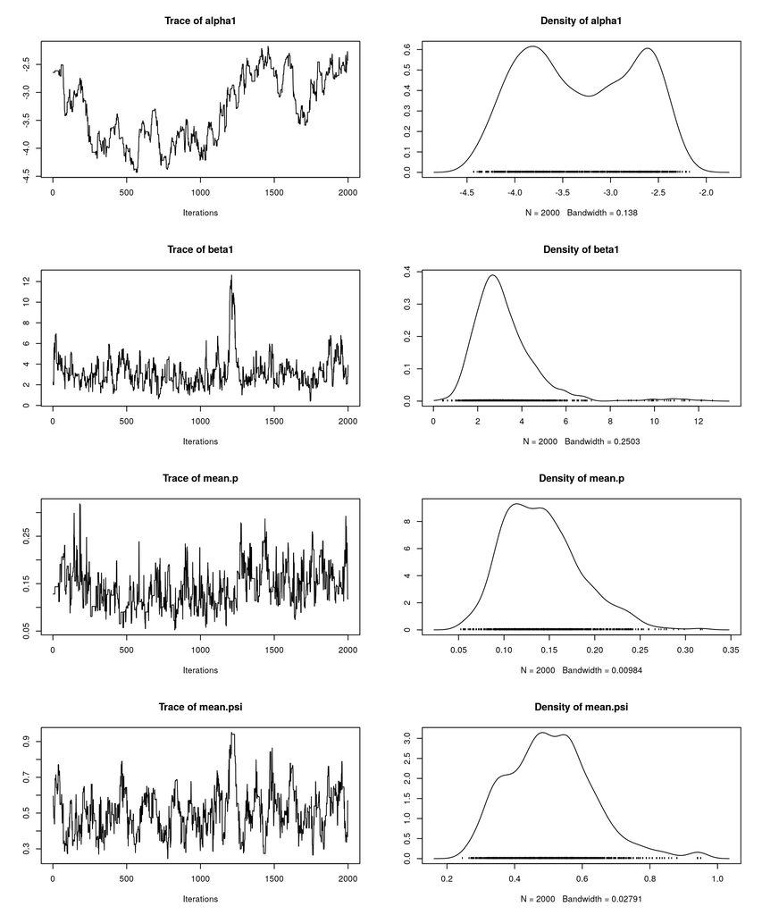

```r
plot(as.mcmc(samples3))
```

# Blocking parameters - getting the initial proposal scale right

Note the warning NIMBLE emitted. The Metropolis-Hastings adaptation scheme can struggle when blocked parameters are on different scales but the proposal scales are initialized to be the same.

```r
conf <- configureMCMC(occ_model)

block  <- c('alpha1','mean.p')
for(p in block)
    conf$removeSamplers(p)
conf$addSampler(block , type = 'RW_block',
                       control = list(propCov = diag(c(.1^2, .01^2))))
```

[output not shown]

```r
occ_MCMC <- buildMCMC(conf)
Cocc_MCMC <- compileNimble(occ_MCMC, project = occ_model, resetFunctions = TRUE)
```

```
## compiling... this may take a minute. Use 'showCompilerOutput = TRUE' to see C++ compilation details.
```

```
## compilation finished.
```

```r
t4 <- system.time(samples4 <- runMCMC(Cocc_MCMC, niter = 2500, nburnin = 500))
```

```
## running chain 1...
```

```
## |-------------|-------------|-------------|-------------|
## |-------------------------------------------------------|
```

```r
effectiveSize(samples4)
```

```
##    alpha1     beta1    mean.p  mean.psi
## 200.72060  83.99510 160.91159  73.09435
```

```r
effectiveSize(samples4) / t4['elapsed']
```

```
##   alpha1    beta1   mean.p mean.psi
## 604.5801 252.9973 484.6735 220.1637
```

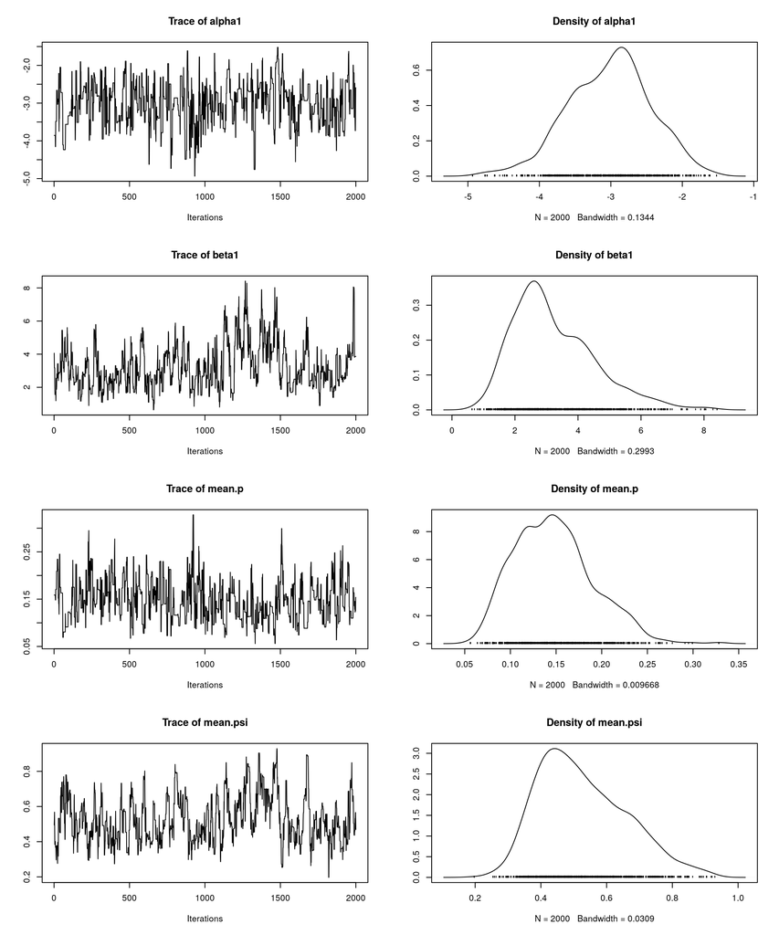

```r
plot(as.mcmc(samples4))
```